# Risk Factor Analysis

## Outcome Variable

**Outcome Variable:** ever_swasted

## Predictor Variables

**Intervention Variable:** mwtkg

**Adjustment Set:**

- arm
- W_mage
- meducyrs
- feducyrs
- W_nchldlt5
- brthmon
- W_parity
- delta_W_mage
- delta_meducyrs
- delta_feducyrs
- delta_W_nchldlt5
- delta_brthmon
- delta_W_parity

## Stratifying Variables

The analysis was stratified on these variable(s):

- agecat
- studyid
- country

## Data Summary

| agecat | studyid | country | mwtkg | ever_swasted | n_cell | n |
| --- | --- | --- | --- | --- | --- | --- |
| 0-24 months | ki0047075b-MAL-ED | BANGLADESH | >=58 kg | 0 | 45 | 254 |
| 0-24 months | ki0047075b-MAL-ED | BANGLADESH | >=58 kg | 1 | 3 | 254 |
| 0-24 months | ki0047075b-MAL-ED | BANGLADESH | <52 kg | 0 | 144 | 254 |
| 0-24 months | ki0047075b-MAL-ED | BANGLADESH | <52 kg | 1 | 18 | 254 |
| 0-24 months | ki0047075b-MAL-ED | BANGLADESH | [52-58) kg | 0 | 44 | 254 |
| 0-24 months | ki0047075b-MAL-ED | BANGLADESH | [52-58) kg | 1 | 0 | 254 |
| 0-24 months | ki0047075b-MAL-ED | BRAZIL | >=58 kg | 0 | 140 | 221 |
| 0-24 months | ki0047075b-MAL-ED | BRAZIL | >=58 kg | 1 | 3 | 221 |
| 0-24 months | ki0047075b-MAL-ED | BRAZIL | <52 kg | 0 | 42 | 221 |
| 0-24 months | ki0047075b-MAL-ED | BRAZIL | <52 kg | 1 | 0 | 221 |
| 0-24 months | ki0047075b-MAL-ED | BRAZIL | [52-58) kg | 0 | 35 | 221 |
| 0-24 months | ki0047075b-MAL-ED | BRAZIL | [52-58) kg | 1 | 1 | 221 |
| 0-24 months | ki0047075b-MAL-ED | INDIA | >=58 kg | 0 | 39 | 242 |
| 0-24 months | ki0047075b-MAL-ED | INDIA | >=58 kg | 1 | 3 | 242 |
| 0-24 months | ki0047075b-MAL-ED | INDIA | <52 kg | 0 | 131 | 242 |
| 0-24 months | ki0047075b-MAL-ED | INDIA | <52 kg | 1 | 19 | 242 |
| 0-24 months | ki0047075b-MAL-ED | INDIA | [52-58) kg | 0 | 46 | 242 |
| 0-24 months | ki0047075b-MAL-ED | INDIA | [52-58) kg | 1 | 4 | 242 |
| 0-24 months | ki0047075b-MAL-ED | NEPAL | >=58 kg | 0 | 78 | 238 |
| 0-24 months | ki0047075b-MAL-ED | NEPAL | >=58 kg | 1 | 2 | 238 |
| 0-24 months | ki0047075b-MAL-ED | NEPAL | <52 kg | 0 | 70 | 238 |
| 0-24 months | ki0047075b-MAL-ED | NEPAL | <52 kg | 1 | 6 | 238 |
| 0-24 months | ki0047075b-MAL-ED | NEPAL | [52-58) kg | 0 | 81 | 238 |
| 0-24 months | ki0047075b-MAL-ED | NEPAL | [52-58) kg | 1 | 1 | 238 |
| 0-24 months | ki0047075b-MAL-ED | PERU | >=58 kg | 0 | 104 | 290 |
| 0-24 months | ki0047075b-MAL-ED | PERU | >=58 kg | 1 | 0 | 290 |
| 0-24 months | ki0047075b-MAL-ED | PERU | <52 kg | 0 | 113 | 290 |
| 0-24 months | ki0047075b-MAL-ED | PERU | <52 kg | 1 | 2 | 290 |
| 0-24 months | ki0047075b-MAL-ED | PERU | [52-58) kg | 0 | 69 | 290 |
| 0-24 months | ki0047075b-MAL-ED | PERU | [52-58) kg | 1 | 2 | 290 |

[output cut: 270 more lines]

The following strata were considered:

- agecat: 0-24 months, studyid: ki0047075b-MAL-ED, country: BANGLADESH
- agecat: 0-24 months, studyid: ki0047075b-MAL-ED, country: BRAZIL
- agecat: 0-24 months, studyid: ki0047075b-MAL-ED, country: INDIA
- agecat: 0-24 months, studyid: ki0047075b-MAL-ED, country: NEPAL
- agecat: 0-24 months, studyid: ki0047075b-MAL-ED, country: PERU
- agecat: 0-24 months, studyid: ki0047075b-MAL-ED, country: SOUTH AFRICA
- agecat: 0-24 months, studyid: ki0047075b-MAL-ED, country: TANZANIA, UNITED REPUBLIC OF
- agecat: 0-24 months, studyid: ki1000304b-SAS-CompFeed, country: INDIA
- agecat: 0-24 months, studyid: ki1017093-NIH-Birth, country: BANGLADESH
- agecat: 0-24 months, studyid: ki1017093b-PROVIDE, country: BANGLADESH
- agecat: 0-24 months, studyid: ki1017093c-NIH-Crypto, country: BANGLADESH
- agecat: 0-24 months, studyid: ki1066203-TanzaniaChild2, country: TANZANIA, UNITED REPUBLIC OF
- agecat: 0-24 months, studyid: ki1112895-iLiNS-Zinc, country: BURKINA FASO
- agecat: 0-24 months, studyid: ki1119695-PROBIT, country: BELARUS
- agecat: 0-24 months, studyid: ki1126311-ZVITAMBO, country: ZIMBABWE
- agecat: 0-24 months, studyid: ki1148112-LCNI-5, country: MALAWI
- agecat: 0-24 months, studyid: kiGH5241-JiVitA-3, country: BANGLADESH
- agecat: 0-6 months, studyid: ki0047075b-MAL-ED, country: BANGLADESH
- agecat: 0-6 months, studyid: ki0047075b-MAL-ED, country: BRAZIL
- agecat: 0-6 months, studyid: ki0047075b-MAL-ED, country: INDIA
- agecat: 0-6 months, studyid: ki0047075b-MAL-ED, country: NEPAL
- agecat: 0-6 months, studyid: ki0047075b-MAL-ED, country: PERU
- agecat: 0-6 months, studyid: ki0047075b-MAL-ED, country: SOUTH AFRICA
- agecat: 0-6 months, studyid: ki0047075b-MAL-ED, country: TANZANIA, UNITED REPUBLIC OF
- agecat: 0-6 months, studyid: ki1000304b-SAS-CompFeed, country: INDIA
- agecat: 0-6 months, studyid: ki1017093-NIH-Birth, country: BANGLADESH
- agecat: 0-6 months, studyid: ki1017093b-PROVIDE, country: BANGLADESH
- agecat: 0-6 months, studyid: ki1017093c-NIH-Crypto, country: BANGLADESH
- agecat: 0-6 months, studyid: ki1066203-TanzaniaChild2, country: TANZANIA, UNITED REPUBLIC OF
- agecat: 0-6 months, studyid: ki1119695-PROBIT, country: BELARUS
- agecat: 0-6 months, studyid: ki1126311-ZVITAMBO, country: ZIMBABWE
- agecat: 0-6 months, studyid: ki1148112-LCNI-5, country: MALAWI
- agecat: 0-6 months, studyid: kiGH5241-JiVitA-3, country: BANGLADESH
- agecat: 6-24 months, studyid: ki0047075b-MAL-ED, country: BANGLADESH
- agecat: 6-24 months, studyid: ki0047075b-MAL-ED, country: BRAZIL
- agecat: 6-24 months, studyid: ki0047075b-MAL-ED, country: INDIA
- agecat: 6-24 months, studyid: ki0047075b-MAL-ED, country: NEPAL
- agecat: 6-24 months, studyid: ki0047075b-MAL-ED, country: PERU
- agecat: 6-24 months, studyid: ki0047075b-MAL-ED, country: SOUTH AFRICA
- agecat: 6-24 months, studyid: ki0047075b-MAL-ED, country: TANZANIA, UNITED REPUBLIC OF
- agecat: 6-24 months, studyid: ki1000304b-SAS-CompFeed, country: INDIA
- agecat: 6-24 months, studyid: ki1017093-NIH-Birth, country: BANGLADESH
- agecat: 6-24 months, studyid: ki1017093b-PROVIDE, country: BANGLADESH
- agecat: 6-24 months, studyid: ki1017093c-NIH-Crypto, country: BANGLADESH
- agecat: 6-24 months, studyid: ki1066203-TanzaniaChild2, country: TANZANIA, UNITED REPUBLIC OF
- agecat: 6-24 months, studyid: ki1112895-iLiNS-Zinc, country: BURKINA FASO
- agecat: 6-24 months, studyid: ki1119695-PROBIT, country: BELARUS
- agecat: 6-24 months, studyid: ki1126311-ZVITAMBO, country: ZIMBABWE
- agecat: 6-24 months, studyid: ki1148112-LCNI-5, country: MALAWI
- agecat: 6-24 months, studyid: kiGH5241-JiVitA-3, country: BANGLADESH

### Dropped Strata

Some strata were dropped due to rare outcomes:

- agecat: 0-24 months, studyid: ki0047075b-MAL-ED, country: BANGLADESH
- agecat: 0-24 months, studyid: ki0047075b-MAL-ED, country: BRAZIL
- agecat: 0-24 months, studyid: ki0047075b-MAL-ED, country: INDIA
- agecat: 0-24 months, studyid: ki0047075b-MAL-ED, country: NEPAL
- agecat: 0-24 months, studyid: ki0047075b-MAL-ED, country: PERU
- agecat: 0-24 months, studyid: ki0047075b-MAL-ED, country: SOUTH AFRICA
- agecat: 0-24 months, studyid: ki0047075b-MAL-ED, country: TANZANIA, UNITED REPUBLIC OF
- agecat: 0-24 months, studyid: ki1017093b-PROVIDE, country: BANGLADESH
- agecat: 0-24 months, studyid: ki1148112-LCNI-5, country: MALAWI
- agecat: 0-6 months, studyid: ki0047075b-MAL-ED, country: BANGLADESH
- agecat: 0-6 months, studyid: ki0047075b-MAL-ED, country: BRAZIL
- agecat: 0-6 months, studyid: ki0047075b-MAL-ED, country: INDIA
- agecat: 0-6 months, studyid: ki0047075b-MAL-ED, country: NEPAL
- agecat: 0-6 months, studyid: ki0047075b-MAL-ED, country: PERU
- agecat: 0-6 months, studyid: ki0047075b-MAL-ED, country: SOUTH AFRICA
- agecat: 0-6 months, studyid: ki0047075b-MAL-ED, country: TANZANIA, UNITED REPUBLIC OF
- agecat: 0-6 months, studyid: ki1017093-NIH-Birth, country: BANGLADESH
- agecat: 0-6 months, studyid: ki1017093b-PROVIDE, country: BANGLADESH
- agecat: 0-6 months, studyid: ki1148112-LCNI-5, country: MALAWI
- agecat: 6-24 months, studyid: ki0047075b-MAL-ED, country: BANGLADESH
- agecat: 6-24 months, studyid: ki0047075b-MAL-ED, country: BRAZIL
- agecat: 6-24 months, studyid: ki0047075b-MAL-ED, country: INDIA
- agecat: 6-24 months, studyid: ki0047075b-MAL-ED, country: NEPAL
- agecat: 6-24 months, studyid: ki0047075b-MAL-ED, country: PERU
- agecat: 6-24 months, studyid: ki0047075b-MAL-ED, country: SOUTH AFRICA
- agecat: 6-24 months, studyid: ki0047075b-MAL-ED, country: TANZANIA, UNITED REPUBLIC OF
- agecat: 6-24 months, studyid: ki1017093-NIH-Birth, country: BANGLADESH
- agecat: 6-24 months, studyid: ki1017093b-PROVIDE, country: BANGLADESH
- agecat: 6-24 months, studyid: ki1017093c-NIH-Crypto, country: BANGLADESH
- agecat: 6-24 months, studyid: ki1119695-PROBIT, country: BELARUS
- agecat: 6-24 months, studyid: ki1148112-LCNI-5, country: MALAWI

## Methods Detail

We’re interested in the causal parameters $E[Y_a]$ for all values of $a \in \mathcal{A}$. These parameters represent the mean outcome if, possibly contrary to fact, we intervened to set all units to have $A=a$. Under the randomization and positivity assumptions, these are identified by the statistical parameters $\psi_a=E_W[E_{Y|A,W}(Y|A=a,W)]$. In addition, we’re interested in the mean of $Y$, $E[Y]$ under no intervention (the observed mean). We will estimate these parameters by using SuperLearner to fit the relevant likelihood factors – $E_{Y|A,W}(Y|A=a,W)$ and $p(A=a|W)$, and then updating our likelihood fit using a joint TMLE.

For unadjusted analyses ($W=\{\}$), initial likelihoods were estimated using Lrnr_glm to estimate the simple $E(Y|A)$ and Lrnr_mean to estimate $p(A)$. For adjusted analyses, a small library containing Lrnr_glmnet, Lrnr_xgboost, and Lrnr_mean was used.

Having estimated these parameters, we will then use the delta method to estimate relative risks and attributable risks relative to a prespecified baseline level of $A$.

# Results Detail

## Results Plots

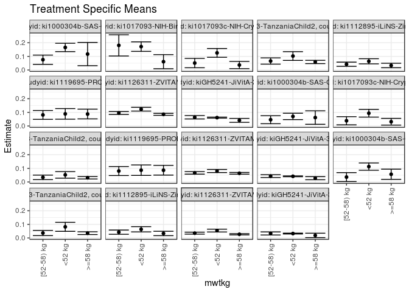

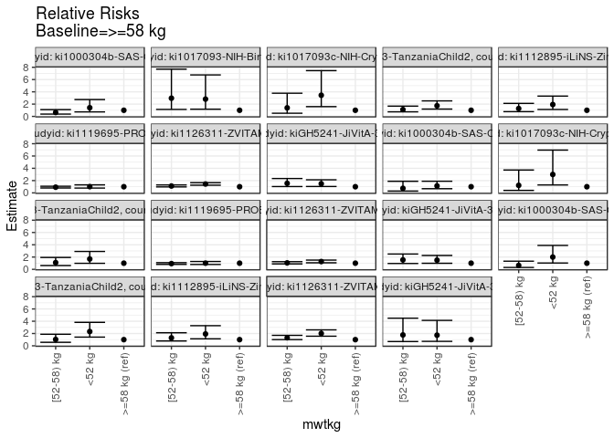

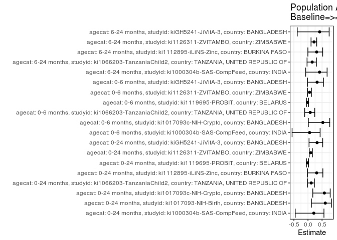

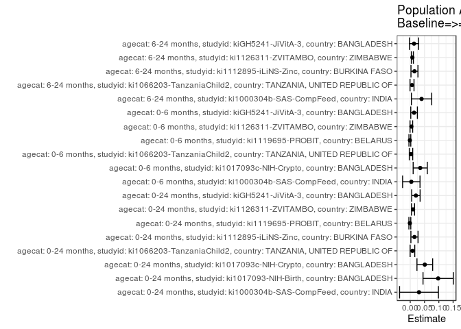

## Results Table

### Parameter: TSM

| agecat | studyid | country | intervention_level | baseline_level | estimate | ci_lower | ci_upper |
| --- | --- | --- | --- | --- | --- | --- | --- |
| 0-24 months | ki1000304b-SAS-CompFeed | INDIA | >=58 kg | NA | 0.1169363 | 0.0315614 | 0.2023112 |
| 0-24 months | ki1000304b-SAS-CompFeed | INDIA | <52 kg | NA | 0.1656898 | 0.1349512 | 0.1964284 |
| 0-24 months | ki1000304b-SAS-CompFeed | INDIA | [52-58) kg | NA | 0.0754164 | 0.0413621 | 0.1094707 |
| 0-24 months | ki1017093-NIH-Birth | BANGLADESH | >=58 kg | NA | 0.0609756 | 0.0091427 | 0.1128086 |
| 0-24 months | ki1017093-NIH-Birth | BANGLADESH | <52 kg | NA | 0.1718750 | 0.1369118 | 0.2068382 |
| 0-24 months | ki1017093-NIH-Birth | BANGLADESH | [52-58) kg | NA | 0.1808511 | 0.1029803 | 0.2587218 |
| 0-24 months | ki1017093c-NIH-Crypto | BANGLADESH | >=58 kg | NA | 0.0364583 | 0.0099295 | 0.0629872 |
| 0-24 months | ki1017093c-NIH-Crypto | BANGLADESH | <52 kg | NA | 0.1256158 | 0.0933571 | 0.1578744 |
| 0-24 months | ki1017093c-NIH-Crypto | BANGLADESH | [52-58) kg | NA | 0.0509554 | 0.0165343 | 0.0853765 |
| 0-24 months | ki1066203-TanzaniaChild2 | TANZANIA, UNITED REPUBLIC OF | >=58 kg | NA | 0.0590073 | 0.0469632 | 0.0710513 |
| 0-24 months | ki1066203-TanzaniaChild2 | TANZANIA, UNITED REPUBLIC OF | <52 kg | NA | 0.1025128 | 0.0704214 | 0.1346042 |
| 0-24 months | ki1066203-TanzaniaChild2 | TANZANIA, UNITED REPUBLIC OF | [52-58) kg | NA | 0.0659622 | 0.0429508 | 0.0889735 |
| 0-24 months | ki1112895-iLiNS-Zinc | BURKINA FASO | >=58 kg | NA | 0.0330755 | 0.0165995 | 0.0495514 |
| 0-24 months | ki1112895-iLiNS-Zinc | BURKINA FASO | <52 kg | NA | 0.0639228 | 0.0449821 | 0.0828634 |
| 0-24 months | ki1112895-iLiNS-Zinc | BURKINA FASO | [52-58) kg | NA | 0.0423865 | 0.0270316 | 0.0577415 |
| 0-24 months | ki1119695-PROBIT | BELARUS | >=58 kg | NA | 0.0878430 | 0.0521239 | 0.1235622 |
| 0-24 months | ki1119695-PROBIT | BELARUS | <52 kg | NA | 0.0888747 | 0.0499545 | 0.1277950 |
| 0-24 months | ki1119695-PROBIT | BELARUS | [52-58) kg | NA | 0.0813396 | 0.0488396 | 0.1138396 |
| 0-24 months | ki1126311-ZVITAMBO | ZIMBABWE | >=58 kg | NA | 0.0855403 | 0.0782826 | 0.0927981 |
| 0-24 months | ki1126311-ZVITAMBO | ZIMBABWE | <52 kg | NA | 0.1234199 | 0.1096796 | 0.1371602 |
| 0-24 months | ki1126311-ZVITAMBO | ZIMBABWE | [52-58) kg | NA | 0.0955426 | 0.0847091 | 0.1063760 |
| 0-24 months | kiGH5241-JiVitA-3 | BANGLADESH | >=58 kg | NA | 0.0413098 | 0.0268586 | 0.0557609 |
| 0-24 months | kiGH5241-JiVitA-3 | BANGLADESH | <52 kg | NA | 0.0614134 | 0.0576898 | 0.0651369 |
| 0-24 months | kiGH5241-JiVitA-3 | BANGLADESH | [52-58) kg | NA | 0.0640642 | 0.0516359 | 0.0764926 |
| 0-6 months | ki1000304b-SAS-CompFeed | INDIA | >=58 kg | NA | 0.0619469 | 0.0123761 | 0.1115177 |
| 0-6 months | ki1000304b-SAS-CompFeed | INDIA | <52 kg | NA | 0.0702371 | 0.0468032 | 0.0936709 |
| 0-6 months | ki1000304b-SAS-CompFeed | INDIA | [52-58) kg | NA | 0.0460251 | 0.0166561 | 0.0753941 |
| 0-6 months | ki1017093c-NIH-Crypto | BANGLADESH | >=58 kg | NA | 0.0312500 | 0.0066227 | 0.0558773 |
| 0-6 months | ki1017093c-NIH-Crypto | BANGLADESH | <52 kg | NA | 0.0935961 | 0.0652454 | 0.1219467 |
| 0-6 months | ki1017093c-NIH-Crypto | BANGLADESH | [52-58) kg | NA | 0.0382166 | 0.0082076 | 0.0682255 |
| 0-6 months | ki1066203-TanzaniaChild2 | TANZANIA, UNITED REPUBLIC OF | >=58 kg | NA | 0.0309066 | 0.0219297 | 0.0398835 |
| 0-6 months | ki1066203-TanzaniaChild2 | TANZANIA, UNITED REPUBLIC OF | <52 kg | NA | 0.0521051 | 0.0280272 | 0.0761830 |
| 0-6 months | ki1066203-TanzaniaChild2 | TANZANIA, UNITED REPUBLIC OF | [52-58) kg | NA | 0.0337858 | 0.0171551 | 0.0504165 |
| 0-6 months | ki1119695-PROBIT | BELARUS | >=58 kg | NA | 0.0863213 | 0.0506268 | 0.1220159 |
| 0-6 months | ki1119695-PROBIT | BELARUS | <52 kg | NA | 0.0866921 | 0.0483549 | 0.1250292 |
| 0-6 months | ki1119695-PROBIT | BELARUS | [52-58) kg | NA | 0.0805078 | 0.0475989 | 0.1134166 |
| 0-6 months | ki1126311-ZVITAMBO | ZIMBABWE | >=58 kg | NA | 0.0636785 | 0.0573089 | 0.0700481 |
| 0-6 months | ki1126311-ZVITAMBO | ZIMBABWE | <52 kg | NA | 0.0804633 | 0.0691858 | 0.0917409 |
| 0-6 months | ki1126311-ZVITAMBO | ZIMBABWE | [52-58) kg | NA | 0.0667857 | 0.0574794 | 0.0760921 |
| 0-6 months | kiGH5241-JiVitA-3 | BANGLADESH | >=58 kg | NA | 0.0279592 | 0.0165383 | 0.0393800 |
| 0-6 months | kiGH5241-JiVitA-3 | BANGLADESH | <52 kg | NA | 0.0416940 | 0.0385193 | 0.0448688 |
| 0-6 months | kiGH5241-JiVitA-3 | BANGLADESH | [52-58) kg | NA | 0.0429498 | 0.0327175 | 0.0531821 |
| 6-24 months | ki1000304b-SAS-CompFeed | INDIA | >=58 kg | NA | 0.0566038 | 0.0190352 | 0.0941723 |
| 6-24 months | ki1000304b-SAS-CompFeed | INDIA | <52 kg | NA | 0.1130104 | 0.0863447 | 0.1396762 |
| 6-24 months | ki1000304b-SAS-CompFeed | INDIA | [52-58) kg | NA | 0.0358744 | 0.0032414 | 0.0685075 |
| 6-24 months | ki1066203-TanzaniaChild2 | TANZANIA, UNITED REPUBLIC OF | >=58 kg | NA | 0.0352347 | 0.0250425 | 0.0454269 |
| 6-24 months | ki1066203-TanzaniaChild2 | TANZANIA, UNITED REPUBLIC OF | <52 kg | NA | 0.0817652 | 0.0486956 | 0.1148347 |
| 6-24 months | ki1066203-TanzaniaChild2 | TANZANIA, UNITED REPUBLIC OF | [52-58) kg | NA | 0.0363085 | 0.0172366 | 0.0553803 |
| 6-24 months | ki1112895-iLiNS-Zinc | BURKINA FASO | >=58 kg | NA | 0.0330836 | 0.0170152 | 0.0491520 |
| 6-24 months | ki1112895-iLiNS-Zinc | BURKINA FASO | <52 kg | NA | 0.0637572 | 0.0443521 | 0.0831622 |
| 6-24 months | ki1112895-iLiNS-Zinc | BURKINA FASO | [52-58) kg | NA | 0.0427151 | 0.0271550 | 0.0582752 |
| 6-24 months | ki1126311-ZVITAMBO | ZIMBABWE | >=58 kg | NA | 0.0270176 | 0.0225140 | 0.0315211 |
| 6-24 months | ki1126311-ZVITAMBO | ZIMBABWE | <52 kg | NA | 0.0542722 | 0.0439175 | 0.0646269 |
| 6-24 months | ki1126311-ZVITAMBO | ZIMBABWE | [52-58) kg | NA | 0.0352959 | 0.0281085 | 0.0424832 |
| 6-24 months | kiGH5241-JiVitA-3 | BANGLADESH | >=58 kg | NA | 0.0186916 | 0.0025656 | 0.0348176 |
| 6-24 months | kiGH5241-JiVitA-3 | BANGLADESH | <52 kg | NA | 0.0322766 | 0.0292544 | 0.0352988 |
| 6-24 months | kiGH5241-JiVitA-3 | BANGLADESH | [52-58) kg | NA | 0.0329670 | 0.0217078 | 0.0442263 |

### Parameter: E(Y)

| agecat | studyid | country | intervention_level | baseline_level | estimate | ci_lower | ci_upper |
| --- | --- | --- | --- | --- | --- | --- | --- |
| 0-24 months | ki1000304b-SAS-CompFeed | INDIA | NA | NA | 0.1475300 | 0.1183178 | 0.1767423 |
| 0-24 months | ki1017093-NIH-Birth | BANGLADESH | NA | NA | 0.1586538 | 0.1299648 | 0.1873429 |
| 0-24 months | ki1017093c-NIH-Crypto | BANGLADESH | NA | NA | 0.0874172 | 0.0672569 | 0.1075775 |
| 0-24 months | ki1066203-TanzaniaChild2 | TANZANIA, UNITED REPUBLIC OF | NA | NA | 0.0667517 | 0.0566626 | 0.0768408 |
| 0-24 months | ki1112895-iLiNS-Zinc | BURKINA FASO | NA | NA | 0.0478707 | 0.0359037 | 0.0598376 |
| 0-24 months | ki1119695-PROBIT | BELARUS | NA | NA | 0.0864798 | 0.0514908 | 0.1214689 |
| 0-24 months | ki1126311-ZVITAMBO | ZIMBABWE | NA | NA | 0.0953617 | 0.0899142 | 0.1008093 |
| 0-24 months | kiGH5241-JiVitA-3 | BANGLADESH | NA | NA | 0.0610956 | 0.0576148 | 0.0645765 |
| 0-6 months | ki1000304b-SAS-CompFeed | INDIA | NA | NA | 0.0657277 | 0.0426068 | 0.0888486 |
| 0-6 months | ki1017093c-NIH-Crypto | BANGLADESH | NA | NA | 0.0662252 | 0.0484753 | 0.0839750 |
| 0-6 months | ki1066203-TanzaniaChild2 | TANZANIA, UNITED REPUBLIC OF | NA | NA | 0.0335884 | 0.0263056 | 0.0408712 |
| 0-6 months | ki1119695-PROBIT | BELARUS | NA | NA | 0.0850276 | 0.0499104 | 0.1201448 |
| 0-6 months | ki1126311-ZVITAMBO | ZIMBABWE | NA | NA | 0.0675481 | 0.0628829 | 0.0722134 |
| 0-6 months | kiGH5241-JiVitA-3 | BANGLADESH | NA | NA | 0.0414120 | 0.0384288 | 0.0443951 |
| 6-24 months | ki1000304b-SAS-CompFeed | INDIA | NA | NA | 0.0962373 | 0.0722060 | 0.1202687 |
| 6-24 months | ki1066203-TanzaniaChild2 | TANZANIA, UNITED REPUBLIC OF | NA | NA | 0.0414560 | 0.0326689 | 0.0502431 |
| 6-24 months | ki1112895-iLiNS-Zinc | BURKINA FASO | NA | NA | 0.0478707 | 0.0359037 | 0.0598376 |
| 6-24 months | ki1126311-ZVITAMBO | ZIMBABWE | NA | NA | 0.0344828 | 0.0308596 | 0.0381059 |
| 6-24 months | kiGH5241-JiVitA-3 | BANGLADESH | NA | NA | 0.0319875 | 0.0290997 | 0.0348754 |

### Parameter: RR

| agecat | studyid | country | intervention_level | baseline_level | estimate | ci_lower | ci_upper |
| --- | --- | --- | --- | --- | --- | --- | --- |
| 0-24 months | ki1000304b-SAS-CompFeed | INDIA | >=58 kg | >=58 kg | 1.0000000 | 1.0000000 | 1.000000 |
| 0-24 months | ki1000304b-SAS-CompFeed | INDIA | <52 kg | >=58 kg | 1.4169232 | 0.7323396 | 2.741449 |
| 0-24 months | ki1000304b-SAS-CompFeed | INDIA | [52-58) kg | >=58 kg | 0.6449355 | 0.3759408 | 1.106402 |
| 0-24 months | ki1017093-NIH-Birth | BANGLADESH | >=58 kg | >=58 kg | 1.0000000 | 1.0000000 | 1.000000 |
| 0-24 months | ki1017093-NIH-Birth | BANGLADESH | <52 kg | >=58 kg | 2.8187500 | 1.1761332 | 6.755486 |
| 0-24 months | ki1017093-NIH-Birth | BANGLADESH | [52-58) kg | >=58 kg | 2.9659574 | 1.1437460 | 7.691309 |
| 0-24 months | ki1017093c-NIH-Crypto | BANGLADESH | >=58 kg | >=58 kg | 1.0000000 | 1.0000000 | 1.000000 |
| 0-24 months | ki1017093c-NIH-Crypto | BANGLADESH | <52 kg | >=58 kg | 3.4454609 | 1.5926859 | 7.453573 |
| 0-24 months | ki1017093c-NIH-Crypto | BANGLADESH | [52-58) kg | >=58 kg | 1.3976342 | 0.5178396 | 3.772175 |
| 0-24 months | ki1066203-TanzaniaChild2 | TANZANIA, UNITED REPUBLIC OF | >=58 kg | >=58 kg | 1.0000000 | 1.0000000 | 1.000000 |
| 0-24 months | ki1066203-TanzaniaChild2 | TANZANIA, UNITED REPUBLIC OF | <52 kg | >=58 kg | 1.7372913 | 1.1955038 | 2.524610 |
| 0-24 months | ki1066203-TanzaniaChild2 | TANZANIA, UNITED REPUBLIC OF | [52-58) kg | >=58 kg | 1.1178653 | 0.7460987 | 1.674876 |
| 0-24 months | ki1112895-iLiNS-Zinc | BURKINA FASO | >=58 kg | >=58 kg | 1.0000000 | 1.0000000 | 1.000000 |
| 0-24 months | ki1112895-iLiNS-Zinc | BURKINA FASO | <52 kg | >=58 kg | 1.9326345 | 1.1283913 | 3.310090 |
| 0-24 months | ki1112895-iLiNS-Zinc | BURKINA FASO | [52-58) kg | >=58 kg | 1.2815106 | 0.7735035 | 2.123157 |
| 0-24 months | ki1119695-PROBIT | BELARUS | >=58 kg | >=58 kg | 1.0000000 | 1.0000000 | 1.000000 |
| 0-24 months | ki1119695-PROBIT | BELARUS | <52 kg | >=58 kg | 1.0117450 | 0.7858442 | 1.302584 |
| 0-24 months | ki1119695-PROBIT | BELARUS | [52-58) kg | >=58 kg | 0.9259652 | 0.7961181 | 1.076990 |
| 0-24 months | ki1126311-ZVITAMBO | ZIMBABWE | >=58 kg | >=58 kg | 1.0000000 | 1.0000000 | 1.000000 |
| 0-24 months | ki1126311-ZVITAMBO | ZIMBABWE | <52 kg | >=58 kg | 1.4428276 | 1.2543069 | 1.659683 |
| 0-24 months | ki1126311-ZVITAMBO | ZIMBABWE | [52-58) kg | >=58 kg | 1.1169303 | 0.9693722 | 1.286950 |
| 0-24 months | kiGH5241-JiVitA-3 | BANGLADESH | >=58 kg | >=58 kg | 1.0000000 | 1.0000000 | 1.000000 |
| 0-24 months | kiGH5241-JiVitA-3 | BANGLADESH | <52 kg | >=58 kg | 1.4866542 | 1.0384940 | 2.128217 |
| 0-24 months | kiGH5241-JiVitA-3 | BANGLADESH | [52-58) kg | >=58 kg | 1.5508250 | 1.0292044 | 2.336813 |
| 0-6 months | ki1000304b-SAS-CompFeed | INDIA | >=58 kg | >=58 kg | 1.0000000 | 1.0000000 | 1.000000 |
| 0-6 months | ki1000304b-SAS-CompFeed | INDIA | <52 kg | >=58 kg | 1.1338267 | 0.6789947 | 1.893333 |
| 0-6 months | ki1000304b-SAS-CompFeed | INDIA | [52-58) kg | >=58 kg | 0.7429767 | 0.2925146 | 1.887134 |
| 0-6 months | ki1017093c-NIH-Crypto | BANGLADESH | >=58 kg | >=58 kg | 1.0000000 | 1.0000000 | 1.000000 |
| 0-6 months | ki1017093c-NIH-Crypto | BANGLADESH | <52 kg | >=58 kg | 2.9950739 | 1.2874825 | 6.967448 |
| 0-6 months | ki1017093c-NIH-Crypto | BANGLADESH | [52-58) kg | >=58 kg | 1.2229299 | 0.4020223 | 3.720086 |
| 0-6 months | ki1066203-TanzaniaChild2 | TANZANIA, UNITED REPUBLIC OF | >=58 kg | >=58 kg | 1.0000000 | 1.0000000 | 1.000000 |
| 0-6 months | ki1066203-TanzaniaChild2 | TANZANIA, UNITED REPUBLIC OF | <52 kg | >=58 kg | 1.6858899 | 0.9767216 | 2.909964 |
| 0-6 months | ki1066203-TanzaniaChild2 | TANZANIA, UNITED REPUBLIC OF | [52-58) kg | >=58 kg | 1.0931591 | 0.6173097 | 1.935814 |
| 0-6 months | ki1119695-PROBIT | BELARUS | >=58 kg | >=58 kg | 1.0000000 | 1.0000000 | 1.000000 |
| 0-6 months | ki1119695-PROBIT | BELARUS | <52 kg | >=58 kg | 1.0042946 | 0.7903328 | 1.276181 |
| 0-6 months | ki1119695-PROBIT | BELARUS | [52-58) kg | >=58 kg | 0.9326519 | 0.8026431 | 1.083719 |
| 0-6 months | ki1126311-ZVITAMBO | ZIMBABWE | >=58 kg | >=58 kg | 1.0000000 | 1.0000000 | 1.000000 |
| 0-6 months | ki1126311-ZVITAMBO | ZIMBABWE | <52 kg | >=58 kg | 1.2635865 | 1.0637036 | 1.501030 |
| 0-6 months | ki1126311-ZVITAMBO | ZIMBABWE | [52-58) kg | >=58 kg | 1.0487955 | 0.8834500 | 1.245087 |
| 0-6 months | kiGH5241-JiVitA-3 | BANGLADESH | >=58 kg | >=58 kg | 1.0000000 | 1.0000000 | 1.000000 |
| 0-6 months | kiGH5241-JiVitA-3 | BANGLADESH | <52 kg | >=58 kg | 1.4912473 | 0.9837699 | 2.260507 |
| 0-6 months | kiGH5241-JiVitA-3 | BANGLADESH | [52-58) kg | >=58 kg | 1.5361612 | 0.9464697 | 2.493256 |
| 6-24 months | ki1000304b-SAS-CompFeed | INDIA | >=58 kg | >=58 kg | 1.0000000 | 1.0000000 | 1.000000 |
| 6-24 months | ki1000304b-SAS-CompFeed | INDIA | <52 kg | >=58 kg | 1.9965179 | 1.0255200 | 3.886890 |
| 6-24 months | ki1000304b-SAS-CompFeed | INDIA | [52-58) kg | >=58 kg | 0.6337818 | 0.3023311 | 1.328607 |
| 6-24 months | ki1066203-TanzaniaChild2 | TANZANIA, UNITED REPUBLIC OF | >=58 kg | >=58 kg | 1.0000000 | 1.0000000 | 1.000000 |
| 6-24 months | ki1066203-TanzaniaChild2 | TANZANIA, UNITED REPUBLIC OF | <52 kg | >=58 kg | 2.3205849 | 1.4113370 | 3.815612 |
| 6-24 months | ki1066203-TanzaniaChild2 | TANZANIA, UNITED REPUBLIC OF | [52-58) kg | >=58 kg | 1.0304737 | 0.5657399 | 1.876969 |
| 6-24 months | ki1112895-iLiNS-Zinc | BURKINA FASO | >=58 kg | >=58 kg | 1.0000000 | 1.0000000 | 1.000000 |
| 6-24 months | ki1112895-iLiNS-Zinc | BURKINA FASO | <52 kg | >=58 kg | 1.9271543 | 1.1340599 | 3.274892 |
| 6-24 months | ki1112895-iLiNS-Zinc | BURKINA FASO | [52-58) kg | >=58 kg | 1.2911266 | 0.7856210 | 2.121898 |
| 6-24 months | ki1126311-ZVITAMBO | ZIMBABWE | >=58 kg | >=58 kg | 1.0000000 | 1.0000000 | 1.000000 |
| 6-24 months | ki1126311-ZVITAMBO | ZIMBABWE | <52 kg | >=58 kg | 2.0087733 | 1.5591807 | 2.588007 |
| 6-24 months | ki1126311-ZVITAMBO | ZIMBABWE | [52-58) kg | >=58 kg | 1.3064035 | 1.0040862 | 1.699745 |
| 6-24 months | kiGH5241-JiVitA-3 | BANGLADESH | >=58 kg | >=58 kg | 1.0000000 | 1.0000000 | 1.000000 |
| 6-24 months | kiGH5241-JiVitA-3 | BANGLADESH | <52 kg | >=58 kg | 1.7267972 | 0.7211387 | 4.134889 |
| 6-24 months | kiGH5241-JiVitA-3 | BANGLADESH | [52-58) kg | >=58 kg | 1.7637362 | 0.6919969 | 4.495346 |

### Parameter: PAR

| agecat | studyid | country | intervention_level | baseline_level | estimate | ci_lower | ci_upper |
| --- | --- | --- | --- | --- | --- | --- | --- |
| 0-24 months | ki1000304b-SAS-CompFeed | INDIA | >=58 kg | NA | 0.0305937 | -0.0373082 | 0.0984956 |
| 0-24 months | ki1017093-NIH-Birth | BANGLADESH | >=58 kg | NA | 0.0976782 | 0.0447291 | 0.1506274 |
| 0-24 months | ki1017093c-NIH-Crypto | BANGLADESH | >=58 kg | NA | 0.0509589 | 0.0235314 | 0.0783864 |
| 0-24 months | ki1066203-TanzaniaChild2 | TANZANIA, UNITED REPUBLIC OF | >=58 kg | NA | 0.0077444 | -0.0003443 | 0.0158332 |
| 0-24 months | ki1112895-iLiNS-Zinc | BURKINA FASO | >=58 kg | NA | 0.0147952 | 0.0023055 | 0.0272850 |
| 0-24 months | ki1119695-PROBIT | BELARUS | >=58 kg | NA | -0.0013632 | -0.0046856 | 0.0019592 |
| 0-24 months | ki1126311-ZVITAMBO | ZIMBABWE | >=58 kg | NA | 0.0098214 | 0.0044727 | 0.0151701 |
| 0-24 months | kiGH5241-JiVitA-3 | BANGLADESH | >=58 kg | NA | 0.0197859 | 0.0050471 | 0.0345246 |
| 0-6 months | ki1000304b-SAS-CompFeed | INDIA | >=58 kg | NA | 0.0037808 | -0.0266346 | 0.0341961 |
| 0-6 months | ki1017093c-NIH-Crypto | BANGLADESH | >=58 kg | NA | 0.0349752 | 0.0102146 | 0.0597358 |
| 0-6 months | ki1066203-TanzaniaChild2 | TANZANIA, UNITED REPUBLIC OF | >=58 kg | NA | 0.0026818 | -0.0033176 | 0.0086813 |
| 0-6 months | ki1119695-PROBIT | BELARUS | >=58 kg | NA | -0.0012937 | -0.0045299 | 0.0019424 |
| 0-6 months | ki1126311-ZVITAMBO | ZIMBABWE | >=58 kg | NA | 0.0038696 | -0.0007455 | 0.0084847 |
| 0-6 months | kiGH5241-JiVitA-3 | BANGLADESH | >=58 kg | NA | 0.0134528 | 0.0019004 | 0.0250052 |
| 6-24 months | ki1000304b-SAS-CompFeed | INDIA | >=58 kg | NA | 0.0396336 | 0.0041026 | 0.0751645 |
| 6-24 months | ki1066203-TanzaniaChild2 | TANZANIA, UNITED REPUBLIC OF | >=58 kg | NA | 0.0062213 | -0.0007612 | 0.0132037 |
| 6-24 months | ki1112895-iLiNS-Zinc | BURKINA FASO | >=58 kg | NA | 0.0147871 | 0.0025920 | 0.0269822 |
| 6-24 months | ki1126311-ZVITAMBO | ZIMBABWE | >=58 kg | NA | 0.0074652 | 0.0039141 | 0.0110163 |
| 6-24 months | kiGH5241-JiVitA-3 | BANGLADESH | >=58 kg | NA | 0.0132959 | -0.0028644 | 0.0294562 |

### Parameter: PAF

| agecat | studyid | country | intervention_level | baseline_level | estimate | ci_lower | ci_upper |
| --- | --- | --- | --- | --- | --- | --- | --- |
| 0-24 months | ki1000304b-SAS-CompFeed | INDIA | >=58 kg | NA | 0.2073728 | -0.4533179 | 0.5677079 |
| 0-24 months | ki1017093-NIH-Birth | BANGLADESH | >=58 kg | NA | 0.6156689 | 0.1221060 | 0.8317446 |
| 0-24 months | ki1017093c-NIH-Crypto | BANGLADESH | >=58 kg | NA | 0.5829388 | 0.1719680 | 0.7899356 |
| 0-24 months | ki1066203-TanzaniaChild2 | TANZANIA, UNITED REPUBLIC OF | >=58 kg | NA | 0.1160185 | -0.0125764 | 0.2282821 |
| 0-24 months | ki1112895-iLiNS-Zinc | BURKINA FASO | >=58 kg | NA | 0.3090667 | -0.0141293 | 0.5292623 |
| 0-24 months | ki1119695-PROBIT | BELARUS | >=58 kg | NA | -0.0157634 | -0.0543065 | 0.0213706 |
| 0-24 months | ki1126311-ZVITAMBO | ZIMBABWE | >=58 kg | NA | 0.1029914 | 0.0453872 | 0.1571196 |
| 0-24 months | kiGH5241-JiVitA-3 | BANGLADESH | >=58 kg | NA | 0.3238506 | 0.0382434 | 0.5246426 |
| 0-6 months | ki1000304b-SAS-CompFeed | INDIA | >=58 kg | NA | 0.0575221 | -0.5639304 | 0.4320306 |
| 0-6 months | ki1017093c-NIH-Crypto | BANGLADESH | >=58 kg | NA | 0.5281250 | 0.0134939 | 0.7742883 |
| 0-6 months | ki1066203-TanzaniaChild2 | TANZANIA, UNITED REPUBLIC OF | >=58 kg | NA | 0.0798444 | -0.1162727 | 0.2415059 |
| 0-6 months | ki1119695-PROBIT | BELARUS | >=58 kg | NA | -0.0152156 | -0.0536624 | 0.0218283 |
| 0-6 months | ki1126311-ZVITAMBO | ZIMBABWE | >=58 kg | NA | 0.0572865 | -0.0134510 | 0.1230867 |
| 0-6 months | kiGH5241-JiVitA-3 | BANGLADESH | >=58 kg | NA | 0.3248527 | -0.0159241 | 0.5513209 |
| 6-24 months | ki1000304b-SAS-CompFeed | INDIA | >=58 kg | NA | 0.4118315 | -0.0801834 | 0.6797375 |
| 6-24 months | ki1066203-TanzaniaChild2 | TANZANIA, UNITED REPUBLIC OF | >=58 kg | NA | 0.1500697 | -0.0328689 | 0.3006068 |
| 6-24 months | ki1112895-iLiNS-Zinc | BURKINA FASO | >=58 kg | NA | 0.3088969 | -0.0031525 | 0.5238775 |
| 6-24 months | ki1126311-ZVITAMBO | ZIMBABWE | >=58 kg | NA | 0.2164901 | 0.1090946 | 0.3109395 |
| 6-24 months | kiGH5241-JiVitA-3 | BANGLADESH | >=58 kg | NA | 0.4156597 | -0.3815110 | 0.7528405 |